# Exploring and comparing Seas Around Us data

# Status of South African marine fishery resources 2023

## Agulhas sole (*Austroglossus pectoralis*)

Agulhas sole SAU landings represents the trends in Agulhas sole catch from 1970-2020 quite close to the data shown in the stock status report from 2023. Particularly the plateu from 1970-2000 and the decline from 2000-2020 are represnted. Magnitudes of catch are fairly well represented.

Agulhas sole SAU landings data.

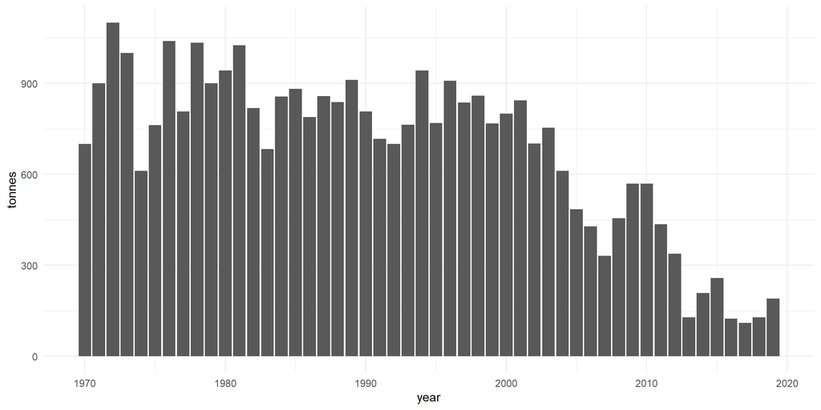

```r
ggplot() +
    geom_col(
        data = landings[landings$scientific_name == "Austroglossus pectoralis", ],
        aes(x = year, y = tonnes)
    ) +
    theme_minimal()
```

Agulhas sole stock status report

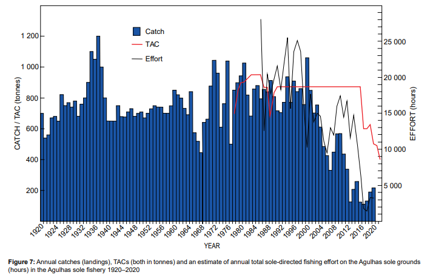

## Cape Hakes (*Merluccius spp*).

Peaks and troughs in trends of Cape Hakes catch are not well represented in Seas-Around-Us landings data.

Cape hake SAU landings data

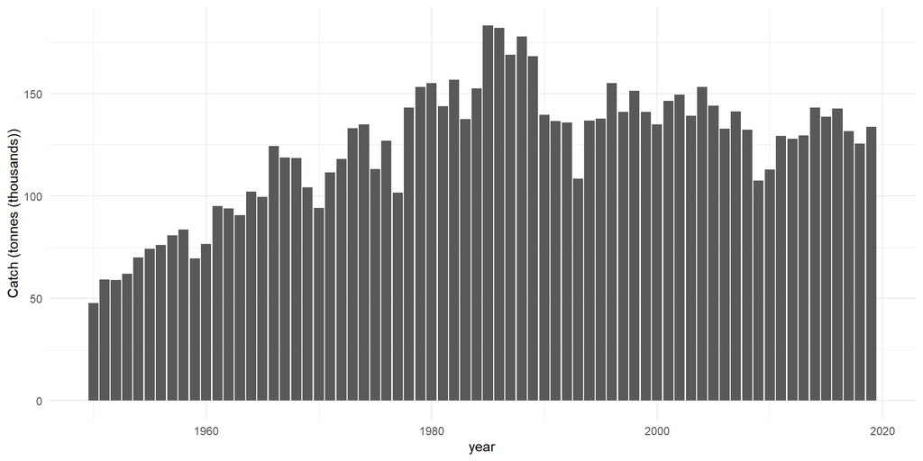

```r
ch_landings <- landings[landings$scientific_name == "Merluccius", ]
ch_landings$tonnes_thousands <- ch_landings$tonnes / 1000
ggplot() +
    geom_col(
        data = ch_landings,
        aes(x = year, y = tonnes_thousands)
    )  +
    theme_minimal() +
    labs(y = "Catch (tonnes (thousands))")
```

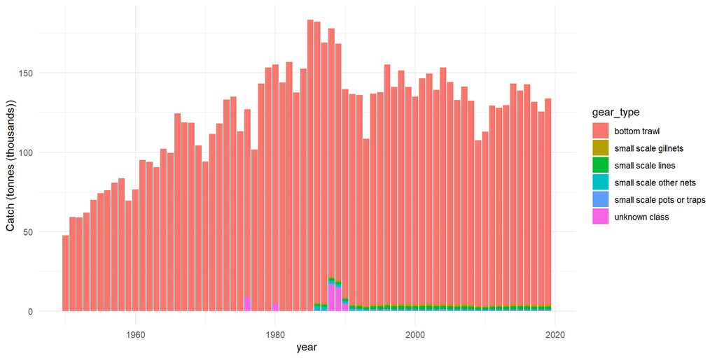

```r
ggplot() +
    geom_col(
        data = ch_landings,
        aes(x = year, y = tonnes_thousands, fill = gear_type)
    )  +
    theme_minimal() +
    labs(y = "Catch (tonnes (thousands))")
```

Cape hakes stock status report

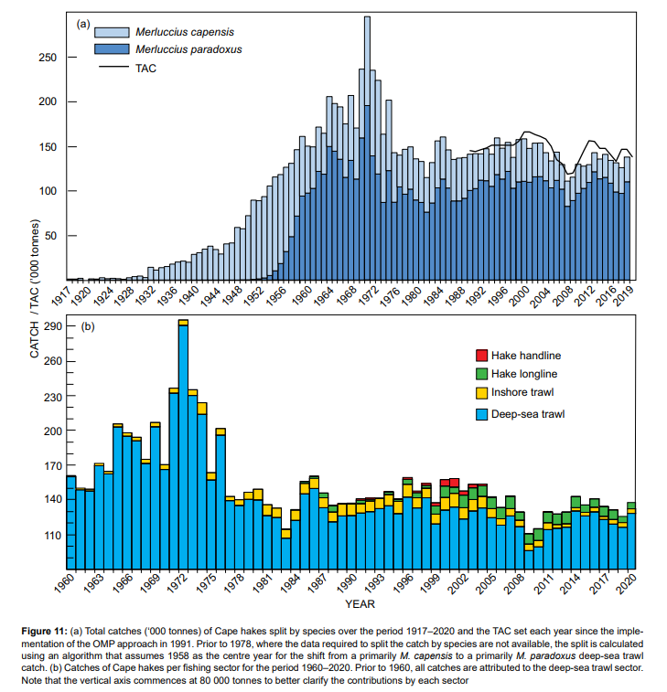

## Cape horse mackerel (*Trachurus capensis*)

The overall trends in total catch for Cape Horse Mackerel are quite well represented, including the decline from 1949-1970s and the peaks and troughs from the 1980s-2020. However, almost all of the catch is collated into pelagic-trawl gear type in Seas-Around-Us data, whereas in the stock status assessment catch is more evenly split (mainly pre and post 1970s) into purse-seine catch and trawl catch.

Cape horse mackerel SAU landings data

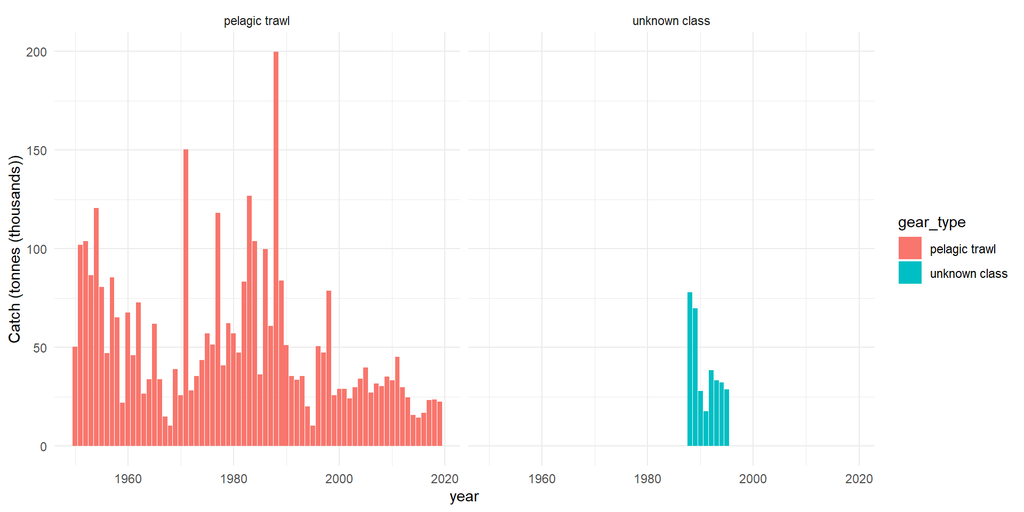

```r
chm_landings <- landings[landings$scientific_name == "Trachurus capensis", ]
chm_landings$tonnes_thousands <- chm_landings$tonnes / 1000
ggplot() +
    geom_col(
        data = chm_landings,
        aes(x = year, y = tonnes_thousands, fill = gear_type)
    )  +
    theme_minimal() +
    facet_wrap(~gear_type) +
    labs(y = "Catch (tonnes (thousands))")
```

Cape horse mackerel stock status report

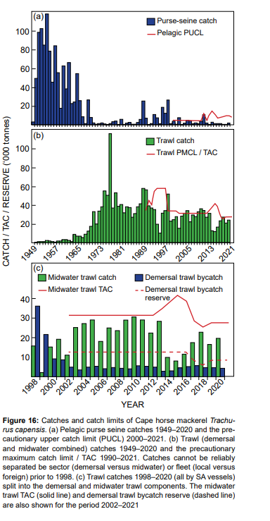

## Monkfish (*Lophius vomerinus*)

Overall Monkfish landings are quite well represented in Seas-Around-Us data. In the peak catch from 1985-1989 SAU data may be overestimating catch, however most other peaks and troughs appear reasonable.

Monkfish SAU landings data

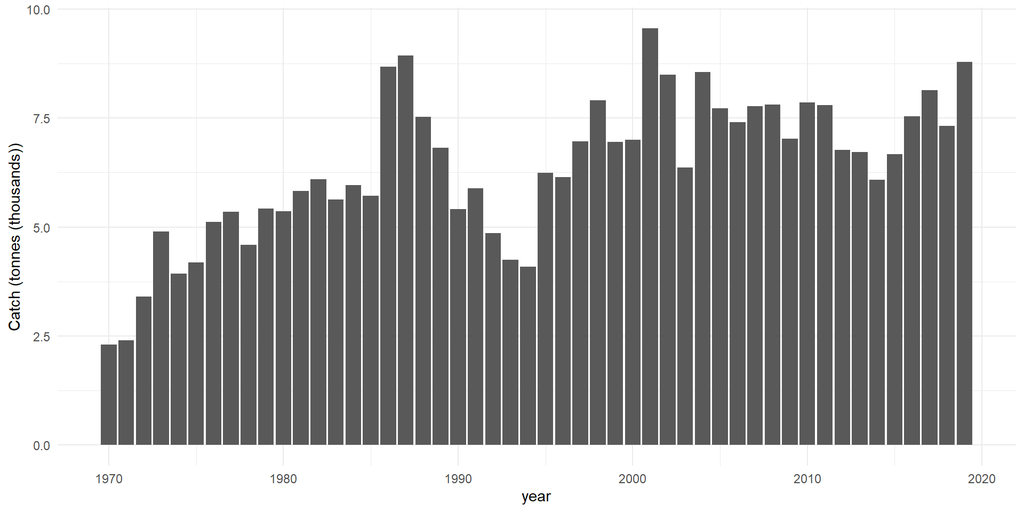

```r
mf_landings <- landings[landings$scientific_name == "Lophius vomerinus", ]
mf_landings$tonnes_thousands <- mf_landings$tonnes / 1000
ggplot() +
    geom_col(
        data = mf_landings,
        aes(x = year, y = tonnes_thousands)
    )  +
    theme_minimal() +
    labs(y = "Catch (tonnes (thousands))")
```

Monkfish stock status report

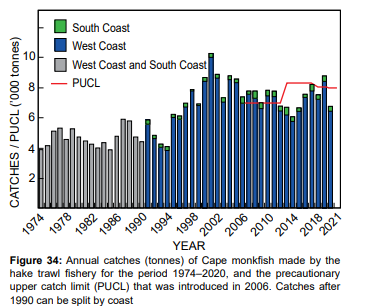

## Small pelagic fish (sardine, anchovy and herring)

Post-1977 catch of small pelagic fish (Engraulis capensis - Anchovy, Sardinops sagax - Sardine and Etrumeus whiteheadi - Herring) are quite well represented in Seas-Around-Us data, including the proportion of the three species in the total catch levels. Before 1977 catch of sardines and anchovies (and total catch) are overestimated in seas-around-us data, and there is a large peak to > 1,500,000 tonnes of catch in SAU, compared with stock status landings for that time which are estimated around 400,000 tonnes and are predominantely sardine.

Small pelagic fish SAU landings data

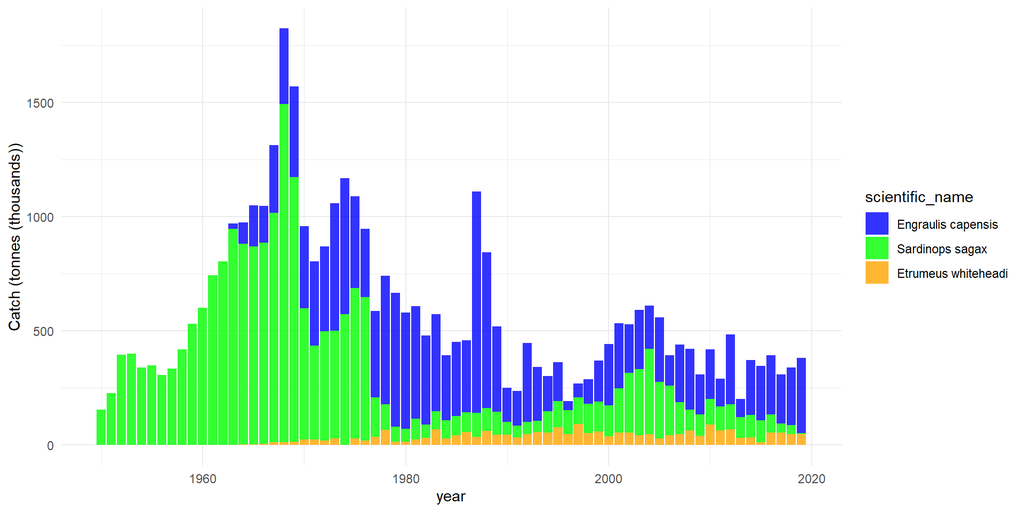

```r
fish <- c("Engraulis capensis" = "blue", "Etrumeus whiteheadi" = "orange", "Sardinops sagax" = "green")
spf_landings <- landings[landings$scientific_name %in% c("Engraulis capensis", "Sardinops sagax", "Etrumeus whiteheadi"), ]
spf_landings$scientific_name <- factor(spf_landings$scientific_name, c("Engraulis capensis", "Sardinops sagax", "Etrumeus whiteheadi"))
spf_landings$tonnes_thousands <- spf_landings$tonnes / 1000

ggplot() +
    geom_col(
        data = spf_landings,
        aes(x = year, y = tonnes_thousands, fill = scientific_name),
        alpha = 0.8
    ) +
    theme_minimal() +
    scale_fill_manual(values = fish) +
    labs(y = "Catch (tonnes (thousands))")
```

Small pelagic fish status report

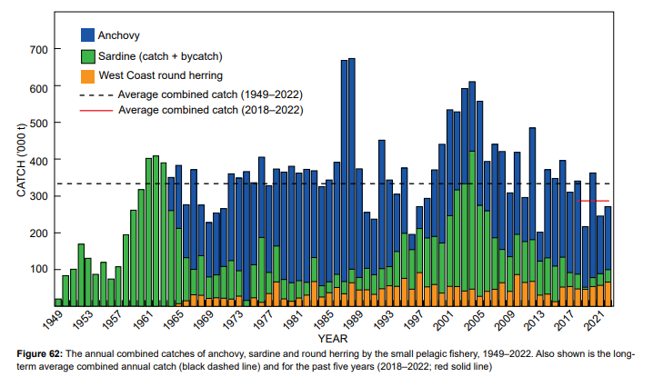

## Squids (Order Teuthida and genus *Loligo*)

Landing data for Squids in the genus *Loligo* are well represented in the Seas-Around-Us data when comparing to data for the genus in the stock status report. Data for other squid species in order Teuthida (first figure) is not represented in the stock status report.

Squids SAU landings data

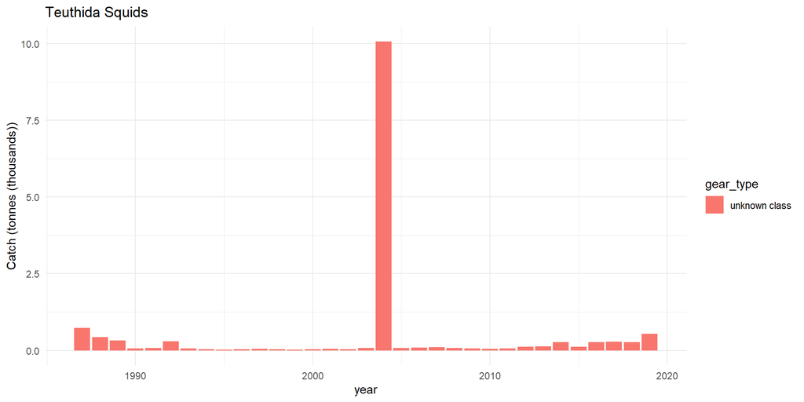

```r
squid_landings <- landings[landings$scientific_name %in% c("Teuthida", "Loligo"), ]
squid_landings$tonnes_thousands <- squid_landings$tonnes / 1000

ggplot() +
    geom_col(
        data = squid_landings[squid_landings$scientific_name == "Teuthida", ],
        aes(x = year, y = tonnes_thousands, fill = gear_type),
        position = "dodge"
    ) +
    theme_minimal() +
    labs(y = "Catch (tonnes (thousands))", title = "Teuthida Squids")
```

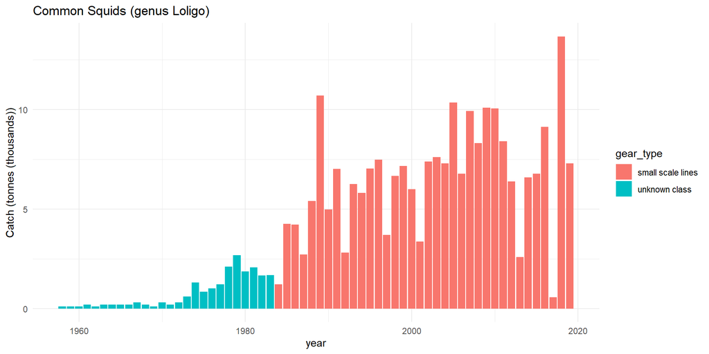

```r
ggplot() +
    geom_col(
        data = squid_landings[squid_landings$scientific_name == "Loligo", ],
        aes(x = year, y = tonnes_thousands, fill = gear_type),
        position = "dodge"
    ) +
    theme_minimal() +
    labs(y = "Catch (tonnes (thousands))", title = "Common Squids (genus Loligo)")
```

Squids stock status report (genus Loligo specified)

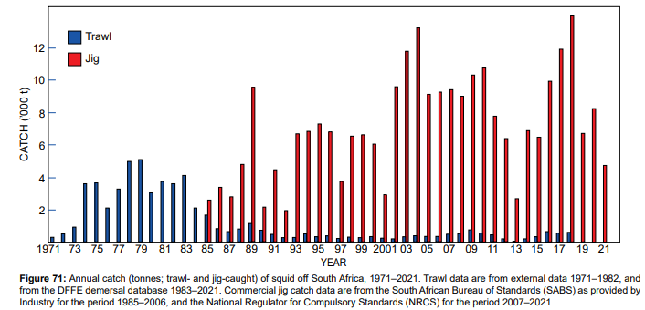

## West Coast Rock Lobster (*Jasus lalandii*)

West coast rock lobster data (refered to as Cape rock lobster in stock status report) in Seas-Around-Us (post 1997 data) matches quite well to the available landings data in the stock status report. However, there is a greater decline in catch between 2019-2022 in the stock status report compared to the SAU data. Data in the stock status report only covers 1998-2022, years before this period are unknown.

West coast rock lobster SAU landings

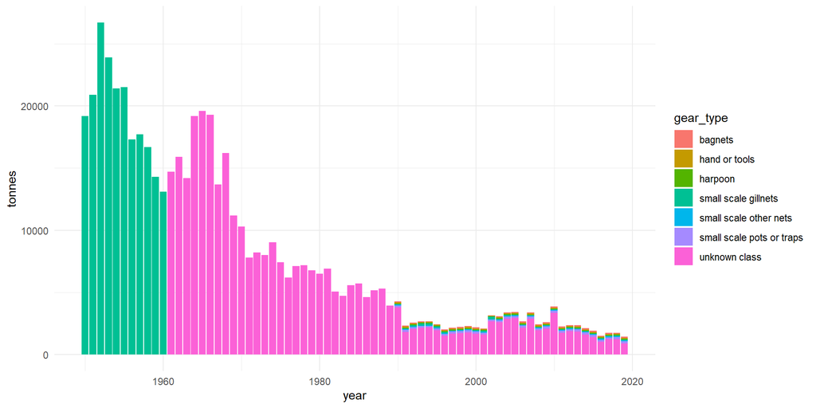

```r
ggplot() +
    geom_col(
        data = landings[landings$scientific_name == "Jasus lalandii", ],
        aes(x = year, y = tonnes, fill = gear_type)
    )  +
    theme_minimal()
```

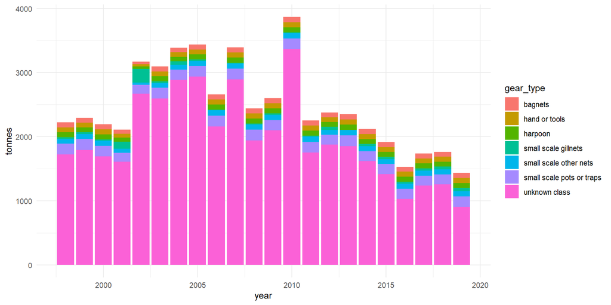

```r
ggplot() +
    geom_col(
        data = landings[landings$scientific_name == "Jasus lalandii" & landings$year > 1997, ],
        aes(x = year, y = tonnes, fill = gear_type)
    ) +
    theme_minimal()
```

West coast rock lobster stock status report 2023

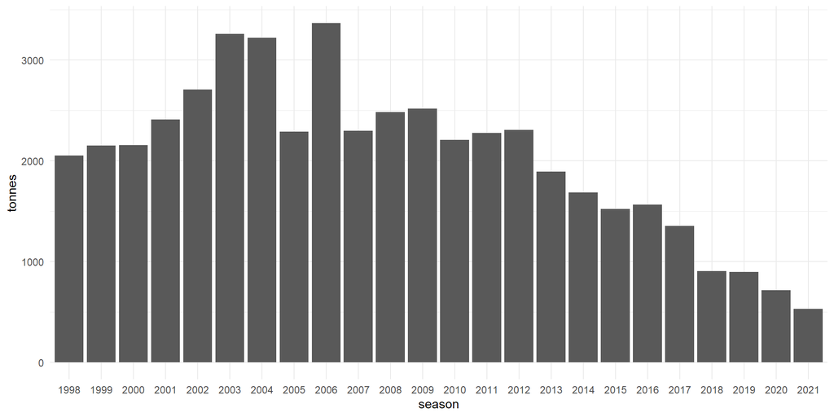

```r
jasus_lalandii$tonnes <- as.numeric(sapply(jasus_lalandii$tonnes, remove_num_space))
jasus_lalandii$season <- sapply(jasus_lalandii$season, function(x) str_split_i(x, "/", 1))
ggplot() +
    geom_col(
        data = jasus_lalandii,
        aes(x = season, y = tonnes)
    )  +
    theme_minimal()
```

## Tuna and large pelagics

Pole and Line landings data for tuna and other large pelagics in Seas-Around-Us data post-2005 match quite well to stock status data for Thunnus alalunga (Albacore) and Yellowfin (Thunnus alabacares). In Seas-Around-Us data there are is a large amount of catch attributed to various small-scale gears, and *Thrysites atun* is only present in these other gears, not in pole and line data. This stock status report data is only available from 2005, so no comparisons of earlier periods can be made.

Pelagic SAU landings data

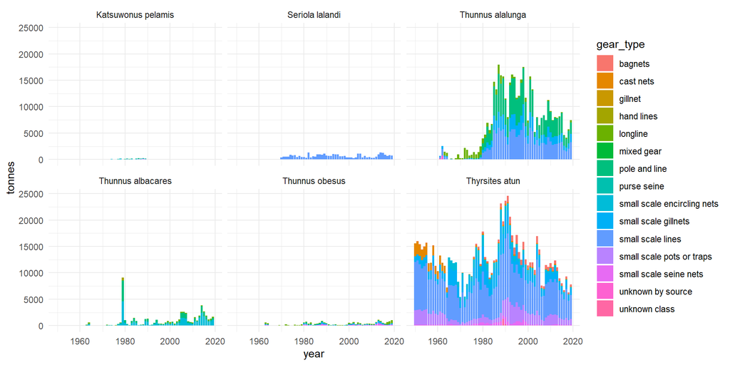

```r
pelagic_species <- sau_species[sau_species %in% names(tuna_catch)]
pelagic_landings <- landings[landings$scientific_name %in% pelagic_species, ]

ggplot() +
    geom_col(
        data = pelagic_landings,
        aes(x = year, y = tonnes, fill = gear_type)
    )  +
    theme_minimal() +
    facet_wrap(~scientific_name)
```

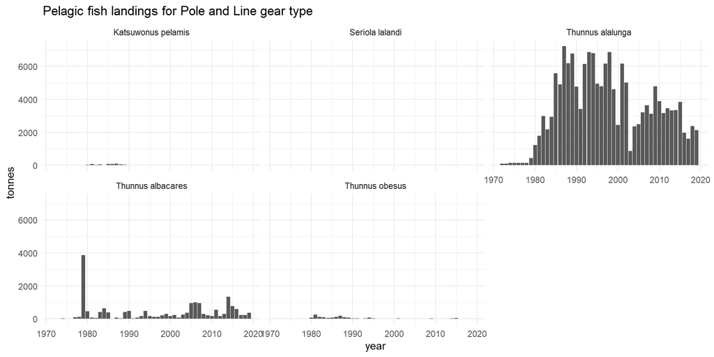

```r
ggplot() +
    geom_col(
        data = pelagic_landings[pelagic_landings$gear_type == "pole and line", ],
        aes(x = year, y = tonnes)
    )  +
    theme_minimal() +
    facet_wrap(~scientific_name) +
    ggtitle("Pelagic fish landings for Pole and Line gear type")
```

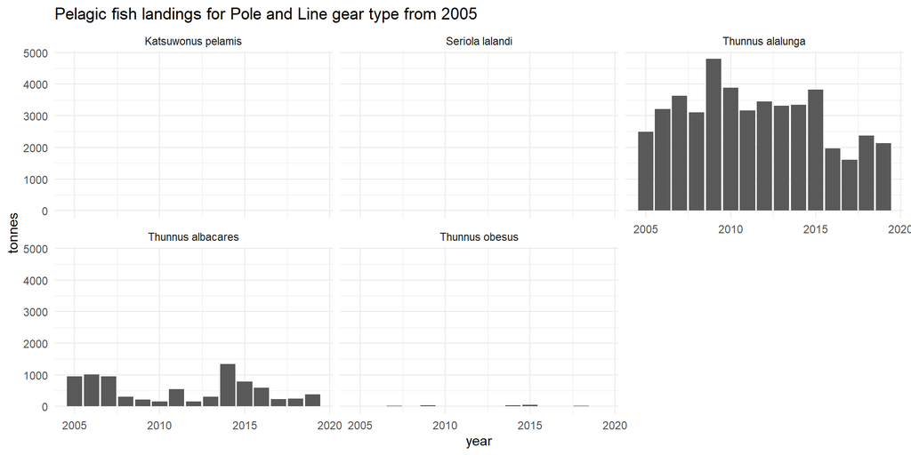

```r
ggplot() +
    geom_col(
        data = pelagic_landings[pelagic_landings$gear_type == "pole and line" & pelagic_landings$year > 2004, ],
        aes(x = year, y = tonnes)
    )  +
    theme_minimal() +
    facet_wrap(~scientific_name) +
    ggtitle("Pelagic fish landings for Pole and Line gear type from 2005")
```

Pelagic stock status report 2023 landings

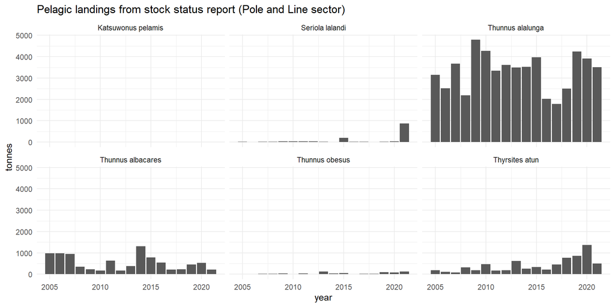

```r
for (name in names(tuna_catch)) {
    if (name %in% pelagic_species){
        tuna_catch[, name] <- as.numeric(sapply(as.vector(unlist(tuna_catch[, name])), remove_num_space))
    }
}

tuna_catch <- tuna_catch %>%
    pivot_longer(
        cols = names(tuna_catch)[names(tuna_catch) %in% pelagic_species],
        names_to = "scientific_name",
        values_to = "tonnes"
    )

ggplot() +
    geom_col(
        data = tuna_catch,
        aes(x = year, y = tonnes)
    )  +
    theme_minimal() +
    facet_wrap(~scientific_name) +
    ggtitle("Pelagic landings from stock status report (Pole and Line sector)")
```

## Soupfin (*Galeorhinus galeus*) and Smoothhound (*Mustelus spp*) sharks

Seas-Around-Us data for Soupfin shark (*Galeorhinus galeus*) does not match well with the corresponding data from the stock status report 2023. Large catch levels from 1990-2000s are missing from data and there is no data pre-1995. Data for Smoothhound shark (*Mustelus spp* in SAU naming) matches fairly well in magnitude and trends overall to the stock status data, with peaks in catch nearing 200 tonnes. However, the attirbution to gear types does not match those in the stock status report, and there is missing data from 1990-2005 and 2013-2017.

Soupfin and Smoothhound sharks SAU landings

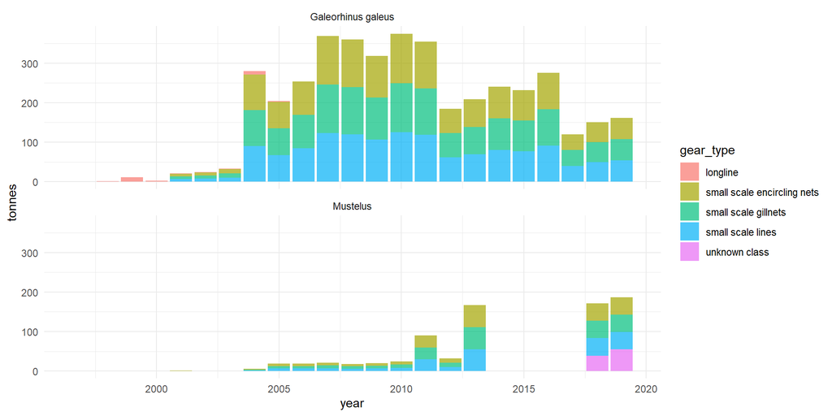

```r
ggplot() +
    geom_col(
        data = landings[landings$scientific_name %in% c("Galeorhinus galeus", "Mustelus"), ],
        aes(x = year, y = tonnes, fill = gear_type),
        alpha = 0.7
    ) +
    theme_minimal() +
    facet_wrap(~scientific_name, ncol = 1)
```

Soupfin and Smoothhound sharks stock status report 2023

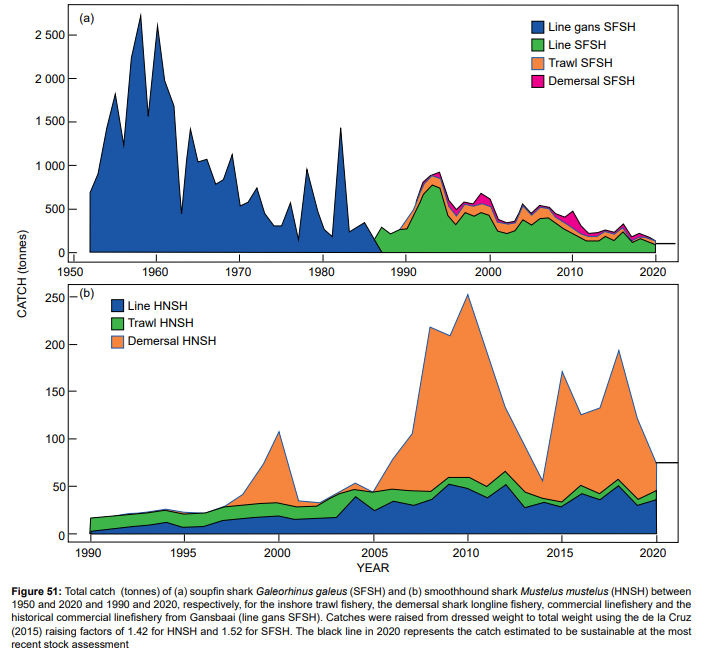

## Kelp harvest

Kelp data is not included in SAU data, but is recorded as ~5,000 tonnes of kelp fronds harvested per year from 1990s-2020s in the stock status report 2023.

# Seas Around Us gear-type distribution versus selected gears

The proposed gear types for South Africa StrathE2E implementation were:

- Purse seine
- demersal trawl (inshore + offshore) + midwater trawl
- linefishery
- squid jig
- pelagic longline
- demersal longline (elasmobranch + hake)

Based on the data from Seas Around Us, possible gear types could be:

- Midwater trawl
- Demersal trawl
- Pole and line (migratory fish)
- Squid jig
- Longline (SAU does not separate pelagic and demersal)
- Purse seine
- West Coast Rock Lobster traps
- Recreational fishing gear
- Small scale lines (roughly corresponds to the South African traditional linefishery)
- Subsistence fishing gears
- Nets (includes gillnets, beach seine, small scale nets etc.)

## Looking at the distribution of landings across gear types in SAU data

Overall the purse-seine gear-type dominates the distribution of landings in SAU data. It is likely that the squid-jig gear type has been labelled “small scale lines” or “unknown class” in SAU data, so these landings are summed with other small scale gear types in the second figure.

When comparing SAU species data with data from the stock status report the gear types in SAU data often did not match the labels given in the stock status reports. This may be due to different language / labels used, or it could be due to incorrect/inconsistent gear-type classification in the SAU data methods.

Distribution of all gear types in Seas-Around-Us data over time.

```r
total_landings <- landings %>%
    group_by(year, gear_type) %>%
    summarise(tonnes = sum(tonnes)) %>%
    group_by(year) %>%
    mutate(proportion = tonnes / sum(tonnes))

palette_n <- distinctColorPalette(length(unique(total_landings$gear_type)))
anim_plot <- ggplot() +
    geom_col(data = total_landings, aes(x = gear_type, y = proportion, fill = gear_type)) +
    transition_states(year) +
    labs(title = "Year: {closest_state}") +
    theme_minimal() +
    theme(
        axis.title.x = element_blank(),
        axis.text.x = element_blank(),
        axis.ticks.x = element_blank()
    ) +
    scale_fill_discrete(palette_n)
```

[output not shown]

Distribution of gear types catch (tonnes) with ‘small-scale’ gears combined in Seas-Around-Us data over time.

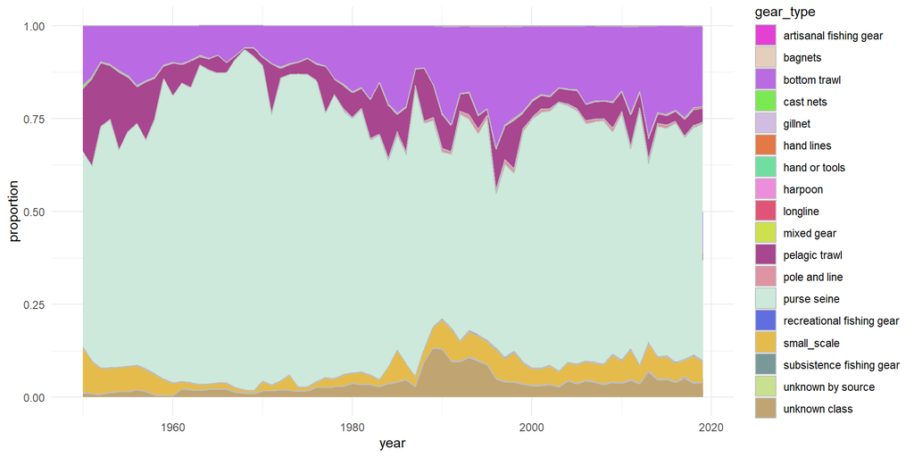

```r
total_landings_small_sum <- total_landings %>%
    mutate(gear_type = if_else(
        str_detect(gear_type, "small scale"),
        "small_scale",
        gear_type
    )) %>%
    group_by(year, gear_type) %>%
    summarise(tonnes = sum(tonnes)) %>%
    mutate(proportion = tonnes / sum(tonnes))
ggplot() +
    geom_area(
        data = total_landings_small_sum,
        aes(x = year, y = proportion, fill = gear_type),
        color = "gray"
    ) +
    theme_minimal() +
    scale_fill_manual(values = palette_n)
```

## Approximating chosen StrathE2E gear classes from SAU data

To compare landings more closely with chosen gear types (above) SAU landings have been collated to approximate these gear types. (Note that a pelagic and a demersal longline class are separate in our proposed gear types, but SAU data only has ‘longline’ (these could be split by Guild caught possibly). And there is no squid jig gear type in SAU data so this label has been given to ‘small scale lines’ as this is the gear type catching *Loligo* squid in SAU data.):

- `nets including small scale` => bagnets, castnets, small scale gillnets, small scale encircling nets, small scale seine nets, small scale other nets, gillnets
- `midwater trawl` => pelagic trawl
- `pole and line` => pole and lines
- `squid jig` => squid jig *
- `longline` => longline
- `purse seine` => purse seine
- `demersal trawl` => bottom trawl
- `WC Rock Lobster traps` => WC Rock Lobster traps *
- `recreational fishing gears` => recreational fishing gears
- `small scale lines` => small scale lines, hand lines
- `subsistence fishing gears` => subsistence fishing gear

**Findings**: Overall `purse seine` gear type dominates distribution of catch (tonnes). Purse seine catch is mainly made up of planktivorous species (see Sardine, Anchovy and Herring). The relative catch levels of all of these gear types remain relatively stable over the timeperiod.

Distribution of catch by these assigned StrathE2E proposed gear types.

```r
# se2e_gear_landings <- landings %>%
#     mutate(gear_type_se2e = case_when(
#         gear_type %in% c("bottom trawl", "pelagic trawl") ~ "demersal + midwater trawl",
#         gear_type %in% c("bagnets", "cast nets", "small scale gillnets", "small scale encircling nets", "small scale seine nets", "small scale other nets", "gillnet") ~ "nets including small scale",
#         gear_type %in% c("hand lines", "pole and line", "recreational fishing gear") ~ "linefishery",
#         gear_type == "small scale lines" ~ "small scale lines / squid jig",
#         gear_type == "longline" ~ "'longline'",
#         gear_type == "purse seine" ~ "purse seine",
#         .default = "other gears"
#     )) %>%
#     group_by(year, gear_type_se2e, Guild) %>%
#     summarise(tonnes = sum(tonnes))

total_se2e_gear_landings <- se2e_gear_landings %>%
    group_by(year, gear_type_se2e) %>%
    summarise(tonnes = sum(tonnes)) %>%
    mutate(proportion = tonnes / sum(tonnes))
```

Landings for StrathE2E approximate proposed gear types for species assigned StrathE2E guilds

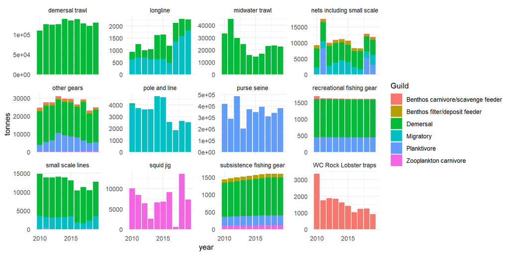

```r
ggplot() +
    geom_col(
        data = se2e_gear_landings[!str_detect(se2e_gear_landings$Guild, "(#)"), ],
        aes(x = year, y = tonnes, fill = Guild)
    )  +
    theme_minimal() +
    facet_wrap(~gear_type_se2e, scales = "free_y") +
    scale_x_continuous(n.breaks=3)
```

Proportion of total landings for StrathE2E approximate gear types over time

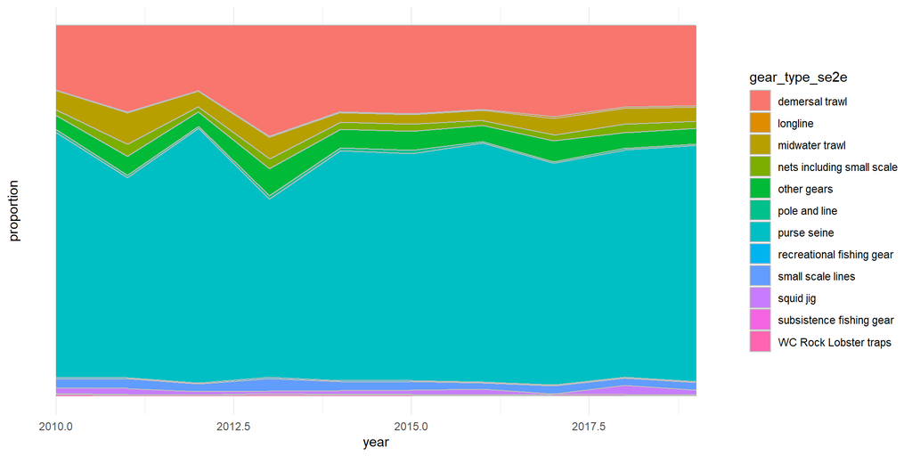

```r
ggplot() +
    geom_area(
        data = total_se2e_gear_landings,
        aes(x = year, y = proportion, fill = gear_type_se2e),
        color = "gray"
    ) +
    scale_y_continuous(breaks = 8) +
    theme_minimal()
```

# Seas Around Us discards data

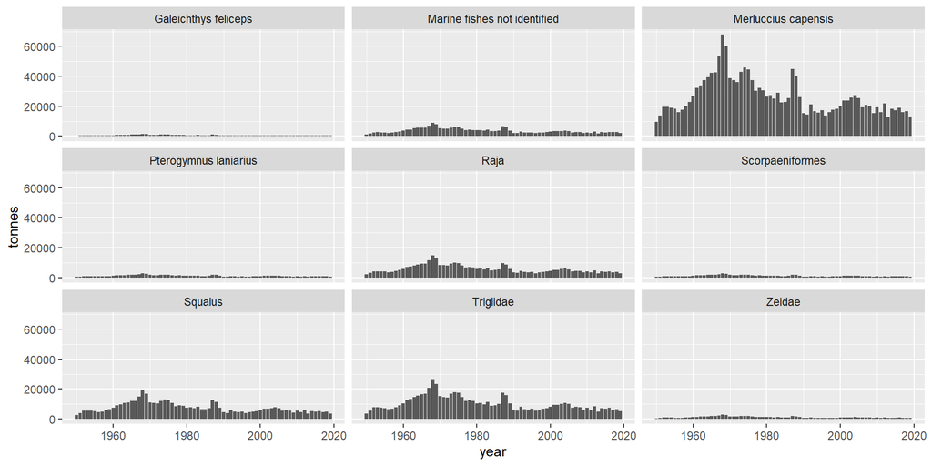

```r
ggplot() +
    geom_col(data = discards, aes(x = year, y = tonnes)) +
    facet_wrap(~scientific_name)
```

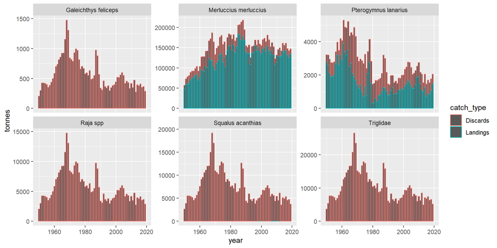

```r
discards <- discards[!is.na(discards$Guild), ]
discard_species_landings <- landings[landings$matched_mimemo_name %in% unique(discards$matched_mimemo_name), ]
discard_species_landings <- data.table::rbindlist(list(discard_species_landings, discards)) %>%
    group_by(matched_mimemo_name, year, Guild, catch_type) %>%
    summarise(tonnes = sum(tonnes))

ggplot() +
    geom_col(
        data = discard_species_landings,
        aes(x = year, y = tonnes, color = catch_type)
    ) +
    facet_wrap(~matched_mimemo_name, scale = "free_y")
```

Discard data is only available for 6 species, and only 2 of those 6 species have meaningful catch amounts in the landing data *Merluccius* and *Pterogymnus*. **All species have the same distributions of discards over time, but at different magnitudes.** However, this may be the only source of landing data that is available for the region.

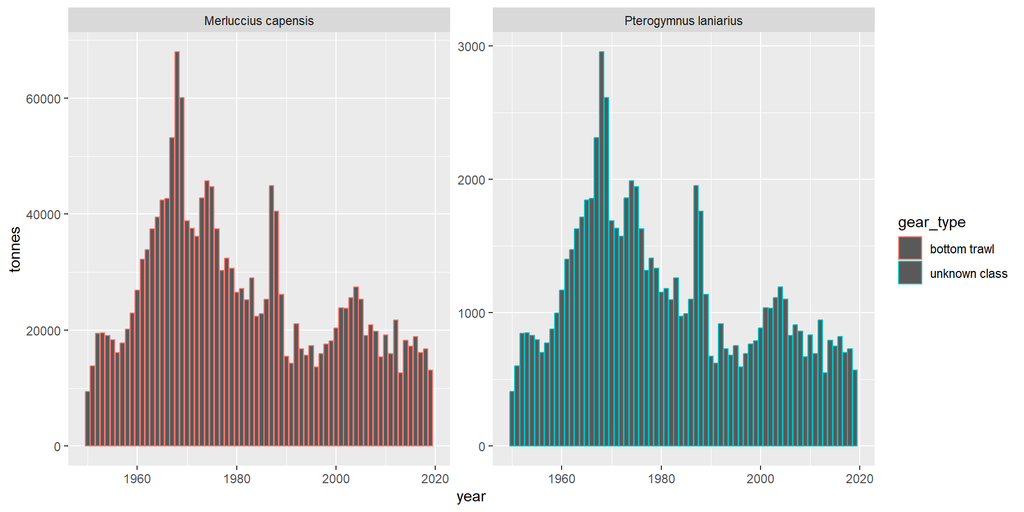

```r
ggplot() +
    geom_col(
        data = discards[discards$scientific_name %in% c("Merluccius capensis", "Pterogymnus laniarius"), ],
        aes(x = year, y = tonnes, color = gear_type)
    ) +
    facet_wrap(~scientific_name, scale = "free_y")
```

# Seas Around Us Data Uncertainty

Seas Around Us represent data uncertainty as a range of qualitative scores (1-4). The data for the southern Benguela region is uncertain, with scores from 1-2 (with most landings being 1). The following uncertainty scores appear in the Seas Around Us landings data:

- `NA` : Unknown uncertainty score.
- `1` : +/- 50%, Low agreement & low evidence.
- `2` : +/- 30%, High agreement & limited evidence or medium agreement & medium evidence or low agreement & robust evidence.

Proportion of yearly gear type landings (tonnes) attributed to each uncertainty score value.

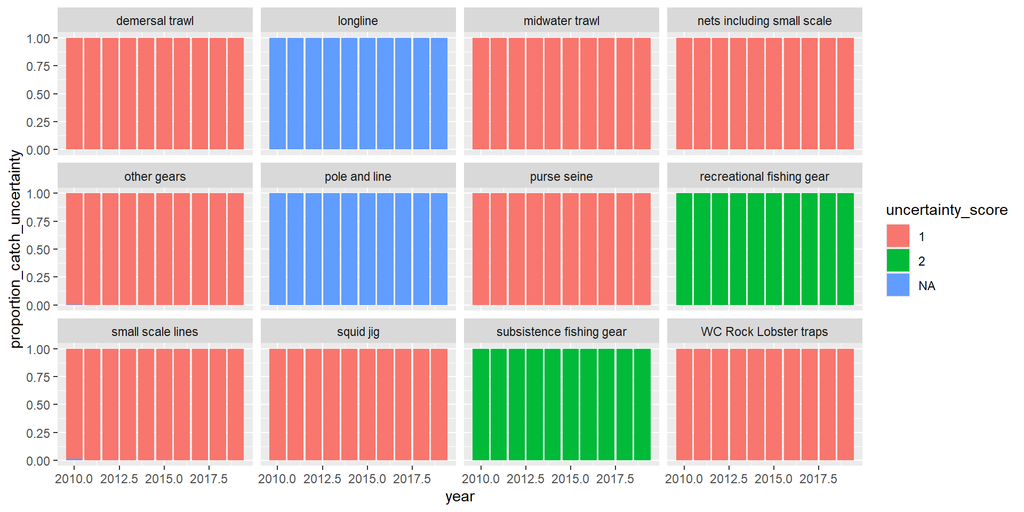

```r
## For each gear type
se2e_gear_landings$uncertainty_score <- as.factor(se2e_gear_landings$uncertainty_score)
se2e_gear_landings$uncertainty_score <- ifelse(is.na(se2e_gear_landings$uncertainty_score), "NA", se2e_gear_landings$uncertainty_score)
year_gear_total_landings <- se2e_gear_landings %>%
    group_by(year, gear_type_se2e) %>%
    summarise(year_sum_tonnes = sum(tonnes))
sau_landings_uncertain_gear <- se2e_gear_landings %>%
    group_by(year, uncertainty_score, gear_type_se2e) %>%
    summarise(tonnes = sum(tonnes)) %>%
    left_join(., year_gear_total_landings, by = c("year", "gear_type_se2e")) %>%
    mutate(proportion_catch_uncertainty = tonnes / year_sum_tonnes)

ggplot() +
    geom_col(
        data = sau_landings_uncertain_gear,
        aes(x = year, y = proportion_catch_uncertainty, fill = uncertainty_score)
    ) +
    facet_wrap(~gear_type_se2e)
```

Proportion of yearly guild landings (tonnes) attributed to each uncertainty score.

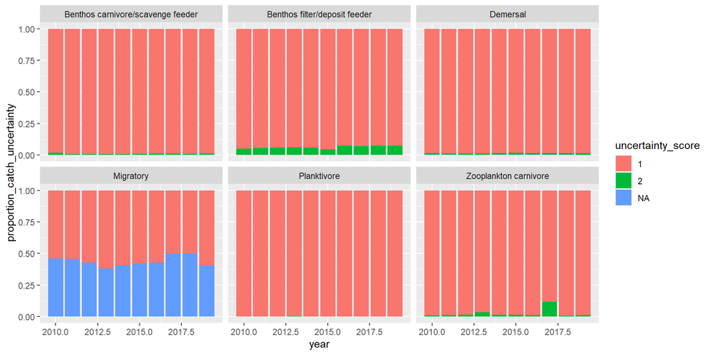

```r
## For each Guild
year_guild_total_landings <- se2e_gear_landings %>%
    group_by(year, Guild) %>%
    summarise(year_sum_tonnes = sum(tonnes))
sau_landings_uncertain_guild <- se2e_gear_landings %>%
    group_by(year, uncertainty_score, Guild) %>%
    summarise(tonnes = sum(tonnes)) %>%
    left_join(., year_guild_total_landings, by = c("year", "Guild")) %>%
    mutate(proportion_catch_uncertainty = tonnes / year_sum_tonnes)

ggplot() +
    geom_col(
        data = sau_landings_uncertain_guild,
        aes(x = year, y = proportion_catch_uncertainty, fill = uncertainty_score)
    ) +
    facet_wrap(~Guild)
```